# Model for Spam Classification

In this tutorial, we look at classifying emails as either spam or ham. We use the [trec07p](https://plg.uwaterloo.ca/~gvcormac/treccorpus07/about.html) data set. It contains about 61,000 emails recorded over a few months.

We will look at:

- Representing text as numerical values using a bag of words model
- Filtering out infrequent words and non-sense words and their effect on the number of features
- Exploring high-dimensional data with dimensionality reduction
- Clustering and finding features associated with clusters
- Experimental setup for a supervised learning problem (classification)
- Training a Logistic Regression model for classification
- Evaluating the predictions from a classification model
- Additional feature engineering to improve model accuracy

```python
# Import libraries we'll be using

%matplotlib inline
%load_ext autoreload
%autoreload 2

import datetime
import glob
import json
import re

import numpy as np
import matplotlib.pyplot as plt
import seaborn as sns
import scipy.sparse as sp
import pandas as pd

from sklearn.cluster import KMeans
from sklearn.decomposition import TruncatedSVD
from sklearn.feature_extraction.text import TfidfVectorizer
from sklearn.linear_model import SGDClassifier
from sklearn.metrics import accuracy_score
from sklearn.metrics import precision_score
from sklearn.metrics import recall_score
from sklearn.metrics import roc_auc_score
from sklearn.metrics import roc_curve
from sklearn.model_selection import train_test_split

from scipy.stats import binom_test
```

## Import Data

In a previous notebook, I converted the messages from raw email files into JSON documents. Emails contain multiple parts including a header (key-value pairs such as the from, to, and subject fields) and a body / attachments. The body may come in text and/or HTML form. I extracted the bodies, and parsed any HTML if needed, so that the JSON documents contain plain text. I created one JSON file per message; the names of the files contain a unique message id. I also added the ham or spam label to each message.

An example message might look like this:

```
{ "from" : "\"RJ Nowling\" <rnowling@something.com>",
  "to" : "a_student@school.edu",
  "subject" : "Spam Classification",
  "body" : "Did you know you can buy a new iPhone?",
  "user-agent" : "Icedove 1.5.0.10 (X11/20070329)",
  "label" : 0,
  "date" : "Tue, 10 Apr 2007 19:25:38 +0000" }
```

A label of 0 indicates ham, while a label of 1 indicates spam.

```python
# Find all json files in a directory, reads them one at a time,
# and returns the message id and deserialized JSON object

def stream_messages(dirname):
    for flname in glob.glob(dirname + "/*.json"):
        start = flname.rfind("_") + 1
        end = flname.rfind(".")
        message_idx = int(flname[start:end])
        with open(flname) as fl:
            message = json.load(fl)
            yield message_idx, message
```

```python
# Scikit-learn requires separate vectors for each field.

stream = stream_messages("json")
bodies = []
labels = []
to_addresses = []
from_addresses = []
msg_indices = []
user_agents = []
dates = []

for message_idx, message in stream:
    bodies.append(message["body"])
    labels.append(message["label"])
    to_addresses.append(message["to"])
    from_addresses.append(message["from"])
    msg_indices.append(message_idx)
    user_agents.append(message["user-agent"])
    dates.append(message["date"])

print("There are %s messages" % len(bodies))
```

```
There are 61097 messages
```

Convert the messages to a dataframe for easier manipulation

```python
df = pd.DataFrame(data = { "bodies" : bodies,
                           "spam" : labels,
                           "to" : to_addresses,
                           "from" : from_addresses,
                           "message_number" : msg_indices,
                           "user_agent" : user_agents,
                           "date" : dates})
```

```python
df.head()
```

|  | bodies | spam | to | from | message_number | user_agent | date |
| --- | --- | --- | --- | --- | --- | --- | --- |
| 0 | David Duffy wrote:\n> On Fri, 29 Jun 2007, Pet... | 0 | David Duffy <David.Duffy@qimr.edu.au> | Peter Dalgaard <p.dalgaard@biostat.ku.dk> | 69863 | Thunderbird 2.0.0.4 (X11/20070615) | Fri, 29 Jun 2007 23:54:09 +0200 |
| 1 | Jord Fara. Yes. It the metal we are faced wi... | 1 | mail@flax9.uwaterloo.ca | "Manuel" <lrxgexvtxn@porterbrown.com> | 73097 | Microsoft Outlook Express 6.00.2900.2869 | Tue, 03 Jul 2007 23:31:26 +0300 |
| 2 | On Jul 4, 2007, at 2:09 AM, Stefan (metze) Met... | 0 | Stefan (metze) Metzmacher <metze@samba.org> | James Peach <jpeach@samba.org> | 74752 | Apple Mail (2.893) | Thu, 5 Jul 2007 09:07:48 -0700 |
| 3 | Greetings Chortled!!.\nHonetsly are no mandatr... | 1 | <chortled@plg.uwaterloo.ca> | "(270) 818-7244 Jonah " <779ulick@liner-innova... | 2366 | Microsoft Office Outlook, Build 11.0.5510 | Tue, 10 Apr 2007 21:29:55 -0200 |
| 4 | It's not wonder that more than 600,000 medic ... | 1 | <241@speedy.uwaterloo.ca> | "Sherre Tschauner" <spookierbaubles@reit.up.pt> | 15241 | Microsoft Office Outlook, Build 11.0.6353 | Fri, 20 Apr 2007 19:51:09 -0060 |

```python
df.info()
```

```
<class 'pandas.core.frame.DataFrame'>
RangeIndex: 61097 entries, 0 to 61096
Data columns (total 7 columns):
bodies            61097 non-null object
spam              61097 non-null int64
to                60709 non-null object
from              61097 non-null object
message_number    61097 non-null int64
user_agent        61097 non-null object
date              61096 non-null object
dtypes: int64(2), object(5)
memory usage: 3.3+ MB
```

The datetimes were parsed as strings rather than `DateTime` objects. We need to write and apply a custom parser function.

```python
def parse_date(date_string):
    """
    Parse a datetimes like

    'Tue, 10 Apr 2007 19:25:38 +0000'
    'Fri, 18 May 2007 12:15:02 -0700 (PDT)'
    '14 May 2007 04:27:55 +0000'
    '2007-06-02 17:35:21'nih

    """

    if date_string is None:
        return None

    # remove trailing "(GMT)"
    if date_string.endswith(")"):
        idx = date_string.rfind(" ")
        date_string = date_string[:idx]

    # remove preceding day of the week
    if "," in date_string:
        idx = date_string.find(",") + 2
        date_string = date_string[idx:]

    # remove timezone offset
    idx = date_string.rfind(" ")
    date_string = date_string[:idx]

    try:
        fmt = "%d %b %Y %H:%M:%S"
        return datetime.datetime.strptime(date_string, fmt)
    except:
        try:
            fmt = "%Y-%m-%d %H:%M:%S"
            return datetime.datetime.strptime(date_string, fmt)
        except:
            return None
```

```python
datetimes = df["date"].apply(parse_date)

# some values are missing.  use today's value since it will be
# later than any true values.  when we split the data based on
# date, these later values will be in the test set which is more
# appropriate than putting them in the testing set

datetimes = datetimes.fillna(datetime.datetime.today())

datetimes.head()
```

```
0    2007-06-29 23:54:09
1    2007-07-03 23:31:26
2    2007-07-05 09:07:48
3    2007-04-10 21:29:55
4    2007-04-20 19:51:09
Name: date, dtype: object
```

```python
df["date"] = datetimes
df.head()
```

|  | bodies | spam | to | from | message_number | user_agent | date |
| --- | --- | --- | --- | --- | --- | --- | --- |
| 0 | David Duffy wrote:\n> On Fri, 29 Jun 2007, Pet... | 0 | David Duffy <David.Duffy@qimr.edu.au> | Peter Dalgaard <p.dalgaard@biostat.ku.dk> | 69863 | Thunderbird 2.0.0.4 (X11/20070615) | 2007-06-29 23:54:09 |
| 1 | Jord Fara. Yes. It the metal we are faced wi... | 1 | mail@flax9.uwaterloo.ca | "Manuel" <lrxgexvtxn@porterbrown.com> | 73097 | Microsoft Outlook Express 6.00.2900.2869 | 2007-07-03 23:31:26 |
| 2 | On Jul 4, 2007, at 2:09 AM, Stefan (metze) Met... | 0 | Stefan (metze) Metzmacher <metze@samba.org> | James Peach <jpeach@samba.org> | 74752 | Apple Mail (2.893) | 2007-07-05 09:07:48 |
| 3 | Greetings Chortled!!.\nHonetsly are no mandatr... | 1 | <chortled@plg.uwaterloo.ca> | "(270) 818-7244 Jonah " <779ulick@liner-innova... | 2366 | Microsoft Office Outlook, Build 11.0.5510 | 2007-04-10 21:29:55 |
| 4 | It's not wonder that more than 600,000 medic ... | 1 | <241@speedy.uwaterloo.ca> | "Sherre Tschauner" <spookierbaubles@reit.up.pt> | 15241 | Microsoft Office Outlook, Build 11.0.6353 | 2007-04-20 19:51:09 |

## Experimental Setup

We will sort the emails by date. In the real world, we can only use emails from the past to predict whether future emails will be spam. We want our experiments to conform to this. We'll use 75% of emails for training, and the remaining 25% for testing.

```python
df = df.sort_values(by="date")
n_messages = len(df)

training_size = int(n_messages * 0.75)

df_train = df.iloc[:training_size, ]
df_test = df.iloc[training_size:, ]

print(n_messages, "total messages")
print(len(df_train), "training messages")
print(len(df_test), "testing messages")

#labels_train, labels_test, bodies_train, bodies_test, from_train, from_test, user_agents_train, user_agents_test = train_test_split(labels, bodies, from_addresses, user_agents)

#print(len(labels_train), "training messages")
#print(len(labels_test), "testing messages")
```

```
61097 total messages
45822 training messages
15275 testing messages
```

## Feature Engineering

We are going to engineer features from the message bodies. We will use a "bag of words" model. We identify all words across all documents and assign a unique index to each word. For each document, we create a vector of 0s and 1s, where a 1 indicates a word is present and 0 indicates a word is absent.

The vectorizer returns a [sparse matrix](https://en.wikipedia.org/wiki/Sparse_matrix). Many words are likely to only be present in a small handful of documents. This leaves a lot of zeros in the matrix. To avoid storing all of those zeros, a sparse matrix only stores the entries with non-zero values. Sparse matrices tend to be more memory efficient when fewer than 1/3 of entries are non-zero. Scipy provides several different forms of [sparse matrix data structures](https://docs.scipy.org/doc/scipy/reference/sparse.html). This is because not all sparse matrices are efficient for all types of operations (e.g., accessing data by row or column, matrix-vector multiplications, etc.).

```python
body_vectorizer = TfidfVectorizer(binary=True, norm=False, use_idf=False)
body_features_train = body_vectorizer.fit_transform(df_train["bodies"])
body_features_test = body_vectorizer.transform(df_test["bodies"])

nonzero_frac = 100. * body_features_train.count_nonzero() / float(body_features_train.shape[0] * body_features_train.shape[1])
# 4 bytes/float, convert to gb
bytes_per_gb = 1024. * 1024. * 1024.
memory_saved = 4. * body_features_train.shape[0] * body_features_train.shape[1] * nonzero_frac / bytes_per_gb

print("Training Feature matrix shape:", body_features_train.shape)
print("Testing Feature matrix shape:", body_features_test.shape)
print("Percentage of non-zero entries: %.2f" % nonzero_frac)
print("Memory saved: %.1f (gb)" % memory_saved)
```

```
Training Feature matrix shape: (45822, 258109)
Testing Feature matrix shape: (15275, 258109)
Percentage of non-zero entries: 0.05
Memory saved: 2.0 (gb)
```

We can often ignore words that are very rare (e.g., only occur in one or two documents). These words are unlikely to be useful since they don't generalize (occur across multiple documents). This reduces the number of features. We must be careful, however, that we don't exclude words that are somewhat rare as those can be informative. Let's look at the document frequencies of the words.

```
Document word counts: [[1.0000e+00 1.0000e+00 1.0000e+00 ... 2.9233e+04 3.0349e+04 3.3793e+04]]
```

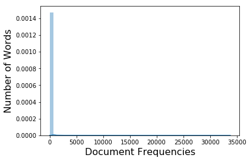

```python
document_counts = body_features_train.sum(axis=0)
document_counts.sort()
print("Document word counts:", document_counts[::-1])

sns.distplot(document_counts)
plt.xlabel("Document Frequencies", size=16)
plt.ylabel("Number of Words", fontsize=16)
```

Most words that occur in only a single or handful of documents! Let's try filtering out words that occur in fewer than 10 documents.

```python
body_vectorizer = TfidfVectorizer(binary=True, norm=False, use_idf=False, min_df=10)
body_features_train = body_vectorizer.fit_transform(df_train["bodies"])
body_features_test = body_vectorizer.transform(df_test["bodies"])

nonzero_frac = 100. * body_features_train.count_nonzero() / float(body_features_train.shape[0] * body_features_train.shape[1])

print("Training Feature matrix shape:", body_features_train.shape)
print("Testing Feature matrix shape:", body_features_test.shape)
print("Percentage of non-zero entries: %.2f" % nonzero_frac)
```

```
Training Feature matrix shape: (45822, 28696)
Testing Feature matrix shape: (15275, 28696)
Percentage of non-zero entries: 0.38
```

When manually looking at some of the messages, I noticed that some messages had "words" that were octal-encoded numbers (e.g., 0x5). These did not seem to be an encoding problem but certainly be difficult to interpret and lead to over-fitting in our model. Let's iterate through our vocabulary and set the counts for any octal words to 0.

```python
# list of vocabulary words, ordered by column index
words = body_vectorizer.get_feature_names()

# remove hex-encoded numbers to simplify interpretation
removed_words = list(filter(lambda pair: pair[1].startswith("0x"), enumerate(words)))

# extract indices of words to remove
removed_indices = [idx for idx, w in removed_words]

# changing the sparsity structure of CSR matrices is inefficient so convert to LIL sparse type
body_features_train_ = body_features_train.tolil()
body_features_test_ = body_features_test.tolil()

# set frequencies for removed words to 0
body_features_train_[:, removed_indices] = 0.0
body_features_test_[:, removed_indices] = 0.0

# convert back to CSR sparse type
body_features_train = body_features_train_.tocsr()
body_features_test = body_features_test_.tocsr()

print("Found", len(removed_words), "octal-encoded words and removed them.")
```

```
Found 1115 octal-encoded words and removed them.
```

## Exploratory Data Analysis

PCA is the most commonly used dimensionality reduction technique. Unfortunately, PCA as implemented in scikit-learn doesn't work on sparse matrices. We'll use SVD, which can be shown to be mathematically equivalent.

```python
svd = TruncatedSVD(n_components = 10)
proj = svd.fit_transform(body_features_train)

print(proj.shape)
print(body_features_train.shape)
```

```
(45822, 10)
(45822, 28696)
```

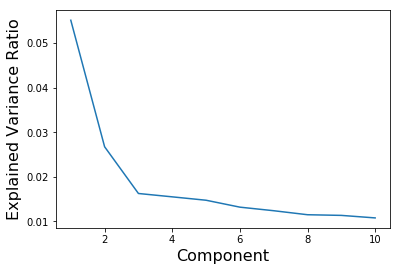

```python
sns.lineplot(range(1, 11), svd.explained_variance_ratio_)
plt.xlabel("Component", fontsize=16)
plt.ylabel("Explained Variance Ratio", fontsize=16)
plt.savefig("eva.pdf", DPI=300)
```

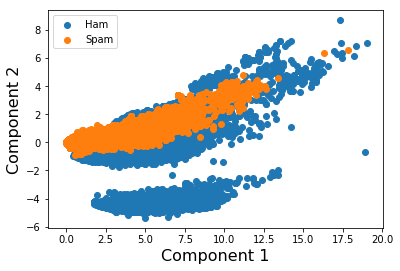

```python
labels_train = np.array(df_train["spam"])
labels_test = np.array(df_test["spam"])
HAM = 0
SPAM = 1
plt.scatter(proj[labels_train == HAM, 0], proj[labels_train == HAM, 1], label="Ham")
plt.scatter(proj[labels_train == SPAM, 0], proj[labels_train == SPAM, 1], label="Spam")
plt.xlabel("Component 1", fontsize=16)
plt.ylabel("Component 2", fontsize=16)
plt.legend()
plt.savefig("svd_labeled.pdf", DPI=300)
```

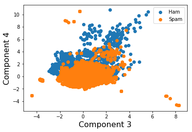

```python
plt.scatter(proj[labels_train == HAM, 2], proj[labels_train == HAM, 3], label="Ham")
plt.scatter(proj[labels_train == SPAM, 2], proj[labels_train == SPAM, 3], label="Spam")
plt.xlabel("Component 3", fontsize=16)
plt.ylabel("Component 4", fontsize=16)
plt.legend()
plt.savefig("svd_labeled_3_4.pdf", DPI=300)
```

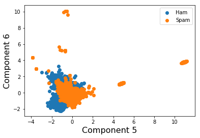

```python
plt.scatter(proj[labels_train == HAM, 4], proj[labels_train == HAM, 5], label="Ham")
plt.scatter(proj[labels_train == SPAM, 4], proj[labels_train == SPAM, 5], label="Spam")
plt.xlabel("Component 5", fontsize=16)
plt.ylabel("Component 6", fontsize=16)
plt.legend()
```

## Clustering

```
2 206547.93111622642
3 115115.15822411743
4 70807.13043824623
5 53656.11862029326
6 43989.08383991524
7 36724.048023195406
8 30903.32408744679
9 27110.802429481846
10 24282.067232198388
11 21664.963837994015
12 19550.795503046873
```

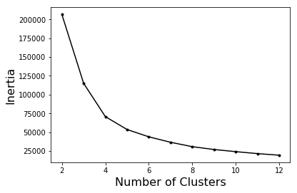

```python
inertias = []
ks = list(range(2, 13))
for k in ks:
    kmeans = KMeans(n_clusters = k)
    kmeans.fit(proj[:, :2])
    inertias.append(kmeans.inertia_)
    print(k, kmeans.inertia_)

plt.plot(ks, inertias, "k.-")
plt.xlabel("Number of Clusters", fontsize=16)
plt.ylabel("Inertia", fontsize=16)
plt.savefig("inertia.pdf", DPI=300)
```

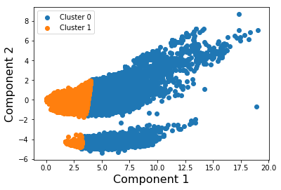

```python
kmeans = KMeans(n_clusters = 2)
kmeans_labels = kmeans.fit_predict(proj[:, :2])

for k in range(2):
    plt.scatter(proj[kmeans_labels == k, 0], proj[kmeans_labels == k, 1], label="Cluster %s" % k)
plt.xlabel("Component 1", fontsize=16)
plt.ylabel("Component 2", fontsize=16)
plt.legend()
plt.savefig("clusters_2.pdf", DPI=300)
```

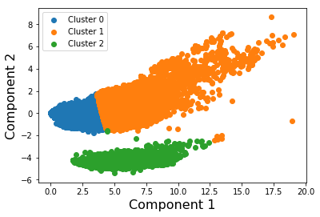

```python
kmeans = KMeans(n_clusters = 3)
kmeans_labels = kmeans.fit_predict(proj[:, :2])

for k in range(3):
    plt.scatter(proj[kmeans_labels == k, 0], proj[kmeans_labels == k, 1], label="Cluster %s" % k)
plt.xlabel("Component 1", fontsize=16)
plt.ylabel("Component 2", fontsize=16)
plt.legend()
plt.savefig("clusters_3.pdf", DPI=300)
```

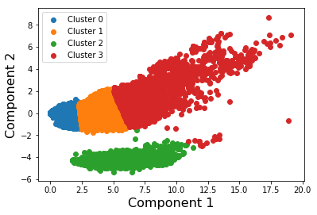

```python
kmeans = KMeans(n_clusters = 4)
kmeans_labels = kmeans.fit_predict(proj[:, :2])

for k in range(4):
    plt.scatter(proj[kmeans_labels == k, 0], proj[kmeans_labels == k, 1], label="Cluster %s" % k)
plt.xlabel("Component 1", fontsize=16)
plt.ylabel("Component 2", fontsize=16)
plt.legend()
plt.savefig("clusters_4.pdf", DPI=300)
```

K-means clustering expects clusters to be circular (Gaussian). It cannot directly partition the messages into the clusters we expect. But we can can use 3 clusters to get close. More than 3 clusters is unnecessary.

We can manually recombine clusters to get the clustering we want.

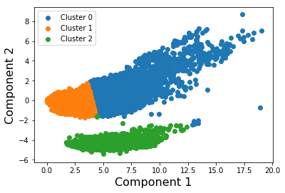

```python
kmeans = KMeans(n_clusters = 3)
kmeans_labels = kmeans.fit_predict(proj[:, :2])

for k in range(3):
    plt.scatter(proj[kmeans_labels == k, 0], proj[kmeans_labels == k, 1], label="Cluster %s" % k)
plt.xlabel("Component 1", fontsize=16)
plt.ylabel("Component 2", fontsize=16)
plt.legend()
```

Clusters 0 and 1 can be recombined into a single cluster. K-Means is initialized randomly, so if we re-run the notebook, the cluster numbers may change.

We will use cluster 0 to mean the top group and cluster 1 to mean the second group. **(Note: cluster ordering can change between re-runs so you may need to manually select which clusters are merged!)**

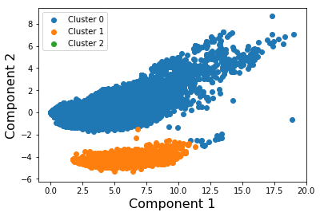

```python
collapsed_labels = np.zeros(kmeans_labels.shape)
collapsed_labels[kmeans_labels == 2] = 1

for k in range(3):
    plt.scatter(proj[collapsed_labels == k, 0], proj[collapsed_labels == k, 1], label="Cluster %s" % k)
plt.xlabel("Component 1", fontsize=16)
plt.ylabel("Component 2", fontsize=16)
plt.legend()
plt.savefig("clusters_2_reassigned.pdf", DPI=300)
```

## Inspecting Clusters

Now, we want to use statistical testing to find which words are associated with each cluster. We'll use a binomial test. Assume we flip two coins many times. The binomial test tells whether the two coins are weighted the same way by comparing the number of heads from one to the other. It gives us a p-value that we can use to perform a test of statistical significance.

For each word, we'll make a 2x2 table with absence / presence along one dimension and cluster along the other.

| Cluster | Absent | Present |
| --- | --- | --- |
| 0 | 500 | 700 |
| 1 | 700 | 500 |

Since cluster 0 is larger, we'll use the counts for cluster 0 to calculate an expected success probability (present) with:

$$ p = \frac{cluster\_0\_present}{cluster\_0\_absent + cluster\_0\_present} $$

```python
cluster_0_docs = body_features_train[collapsed_labels == 0, :]
cluster_1_docs = body_features_train[collapsed_labels == 1, :]
print("Cluster 0:", cluster_0_docs.shape)
print("Cluster 1:", cluster_1_docs.shape)
```

```
Cluster 0: (41502, 28696)
Cluster 1: (4320, 28696)
```

```python
cluster_0_counts = cluster_0_docs.sum(axis=0)
cluster_1_counts = cluster_1_docs.sum(axis=0)
```

```python
word_idx = 0
cluster_0_present = cluster_0_counts[0, word_idx]
cluster_0_absent = cluster_0_docs.shape[0] - cluster_0_present

cluster_1_present = cluster_1_counts[0, word_idx]
cluster_1_absent = cluster_1_docs.shape[0] - cluster_1_present

print(np.array([[cluster_0_absent, cluster_0_present], [cluster_1_absent, cluster_1_present]]))
```

```
[[39321.  2181.]
 [ 4186.   134.]]
```

```python
p = cluster_0_present / (cluster_0_absent + cluster_0_present)
pvalue = binom_test([cluster_1_present, cluster_1_absent], p = p)

print(pvalue)
```

```
1.00712710438019e-11
```

```python
# occurs more frequently in cluster 1 than cluster 0
pvalues_greater = []

# occurs more frequently in cluster 0 than cluster 1
pvalues_less = []

n_words = body_features_train.shape[1]

# significance threshold
alpha = 0.001

# list of vocabulary words, ordered by column index
words = body_vectorizer.get_feature_names()

for word_idx in range(n_words):
    cluster_0_present = cluster_0_counts[0, word_idx]
    cluster_0_absent = cluster_0_docs.shape[0] - cluster_0_present

    cluster_1_present = cluster_1_counts[0, word_idx]
    cluster_1_absent = cluster_1_docs.shape[0] - cluster_1_present

    # expected probability based on cluster 0
    p = cluster_0_present / (cluster_0_absent + cluster_0_present)

    if p == 0.0:
        continue

    # run binomial tests
    pvalue_greater = binom_test([cluster_1_present, cluster_1_absent], p = p, alternative="greater")
    pvalue_less = binom_test([cluster_1_present, cluster_1_absent], p = p, alternative="less")

    # correct for multiple hypothesis testing (Bonferroni)
    corrected_pvalue_greater = pvalue_greater * n_words
    corrected_pvalue_less = pvalue_less * n_words

    if corrected_pvalue_greater < alpha:
        pvalues_greater.append((pvalue_greater, word_idx, words[word_idx], cluster_0_present, cluster_1_present))

    if corrected_pvalue_less < alpha:
        pvalues_less.append((pvalue_less, word_idx, words[word_idx], cluster_0_present, cluster_1_present))

pvalues_greater.sort()
pvalues_less.sort()
```

```python
print(len(pvalues_greater), len(pvalues_less))
```

```
2100 1775
```

```python
pvalues_greater_df = pd.DataFrame(data=pvalues_greater, columns=["p_value", "word_idx", "word", "cluster_0_count", "cluster_1_count"])
pvalues_greater_df.head(30)
```

|  | p_value | word_idx | word | cluster_0_count | cluster_1_count |
| --- | --- | --- | --- | --- | --- |
| 0 | 0.0 | 1713 | 1865 | 9.0 | 229.0 |
| 1 | 0.0 | 2172 | 272595 | 1.0 | 228.0 |
| 2 | 0.0 | 2173 | 272861 | 1.0 | 228.0 |
| 3 | 0.0 | 2174 | 272866 | 1.0 | 228.0 |
| 4 | 0.0 | 2502 | 3tg | 1.0 | 228.0 |
| 5 | 0.0 | 3507 | ______________________________________________ | 10.0 | 4253.0 |
| 6 | 0.0 | 3694 | ac | 159.0 | 418.0 |
| 7 | 0.0 | 3986 | advance | 275.0 | 455.0 |
| 8 | 0.0 | 4328 | alternative | 423.0 | 1085.0 |
| 9 | 0.0 | 4346 | am | 4202.0 | 1662.0 |
| 10 | 0.0 | 4448 | and | 24925.0 | 4308.0 |
| 11 | 0.0 | 5787 | biostatistics | 2.0 | 139.0 |
| 12 | 0.0 | 6079 | bounces | 45.0 | 434.0 |
| 13 | 0.0 | 6407 | but | 9805.0 | 2555.0 |
| 14 | 0.0 | 6785 | cbind | 5.0 | 168.0 |
| 15 | 0.0 | 6923 | ch | 257.0 | 4318.0 |
| 16 | 0.0 | 7479 | code | 2212.0 | 4318.0 |
| 17 | 0.0 | 7593 | columns | 107.0 | 328.0 |
| 18 | 0.0 | 7642 | commented | 184.0 | 4317.0 |
| 19 | 0.0 | 8057 | contained | 397.0 | 4317.0 |
| 20 | 0.0 | 8415 | cran | 8.0 | 220.0 |
| 21 | 0.0 | 8866 | data | 1776.0 | 1836.0 |
| 22 | 0.0 | 8881 | dataset | 17.0 | 234.0 |
| 23 | 0.0 | 8882 | datasets | 8.0 | 176.0 |
| 24 | 0.0 | 9142 | deleted | 150.0 | 1031.0 |
| 25 | 0.0 | 9818 | do | 8285.0 | 4320.0 |
| 26 | 0.0 | 10870 | error | 1526.0 | 998.0 |
| 27 | 0.0 | 10982 | ethz | 13.0 | 4318.0 |
| 28 | 0.0 | 11090 | example | 1323.0 | 957.0 |
| 29 | 0.0 | 11527 | fax | 274.0 | 672.0 |

```python
pvalues_less_df = pd.DataFrame(data=pvalues_less, columns=["p_value", "word_idx", "word", "cluster_0_count", "cluster_1_count"])
pvalues_less_df.head(30)
```

|  | p_value | word_idx | word | cluster_0_count | cluster_1_count |
| --- | --- | --- | --- | --- | --- |
| 0 | 1.499355e-301 | 19177 | our | 8877.0 | 102.0 |
| 1 | 4.227784e-256 | 27033 | unsubscribe | 5384.0 | 2.0 |
| 2 | 1.754986e-191 | 20724 | price | 5244.0 | 39.0 |
| 3 | 1.012357e-174 | 18281 | news | 5335.0 | 58.0 |
| 4 | 2.665537e-158 | 27136 | us | 6989.0 | 165.0 |
| 5 | 1.073231e-157 | 27878 | we | 12009.0 | 517.0 |
| 6 | 5.158032e-148 | 17664 | money | 3915.0 | 23.0 |
| 7 | 4.619484e-147 | 7337 | click | 5421.0 | 92.0 |
| 8 | 1.277998e-140 | 27475 | viagra | 2982.0 | 0.0 |
| 9 | 3.187403e-140 | 18930 | online | 4684.0 | 63.0 |
| 10 | 1.583860e-138 | 22845 | samba | 2939.0 | 0.0 |
| 11 | 3.560208e-133 | 23375 | service | 3571.0 | 22.0 |
| 12 | 1.934576e-130 | 4214 | alert | 2824.0 | 1.0 |
| 13 | 1.362440e-129 | 17213 | men | 2934.0 | 4.0 |
| 14 | 8.980369e-129 | 27224 | uwaterloo | 2738.0 | 0.0 |
| 15 | 1.233673e-128 | 27591 | visit | 3419.0 | 20.0 |
| 16 | 1.162947e-121 | 22294 | revision | 2806.0 | 5.0 |
| 17 | 5.656221e-121 | 8051 | contact | 4224.0 | 62.0 |
| 18 | 7.819930e-111 | 21549 | ready | 3006.0 | 19.0 |
| 19 | 1.295641e-109 | 6419 | buy | 3857.0 | 57.0 |
| 20 | 5.573950e-108 | 24385 | speedy | 2306.0 | 0.0 |
| 21 | 1.061397e-104 | 22392 | rights | 2614.0 | 10.0 |
| 22 | 5.825909e-103 | 22111 | reserved | 2201.0 | 0.0 |
| 23 | 4.636524e-101 | 13541 | her | 2654.0 | 14.0 |
| 24 | 5.987456e-97 | 6921 | cgi | 2384.0 | 8.0 |
| 25 | 1.754567e-96 | 8909 | day | 6098.0 | 209.0 |
| 26 | 4.092766e-96 | 16134 | life | 3332.0 | 47.0 |
| 27 | 5.864881e-95 | 7181 | cialis | 2033.0 | 0.0 |
| 28 | 8.861183e-91 | 28333 | world | 3737.0 | 74.0 |
| 29 | 4.079035e-90 | 6572 | canadian | 1931.0 | 0.0 |

## Machine Learning Model

```python
sgd = SGDClassifier(loss="log", max_iter=1000, tol=1e-3)
sgd.fit(body_features_train, df_train["spam"].values)

labels_pred = sgd.predict(body_features_test)
pred_prob = sgd.predict_proba(body_features_test)
```

## Model Evaluation

```python
accuracy = accuracy_score(df_test["spam"].values, labels_pred)
precision = precision_score(df_test["spam"].values, labels_pred)
recall = recall_score(labels_test, labels_pred)

print("Accuracy:", accuracy)
print("Precision:", precision)
print("Recall:", recall)
```

```
Accuracy: 0.9910965630114567
Precision: 0.9895790764201062
Recall: 0.9965020576131687
```

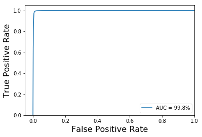

```python
# SGDClassifier returns probabilities for positive and negative classes
# so pred_prob has a shape of samples x 2.  Grab probabilities of spam
# because that is our positive class
fpr, tpr, _ = roc_curve(df_test["spam"].values, pred_prob[:, SPAM])
roc_auc = 100. * roc_auc_score(df_test["spam"].values, pred_prob[:, SPAM])

sns.lineplot(fpr, tpr, label="AUC = %.1f%%" % roc_auc)
# leave some room on the top and left so we can see the curve
plt.xlim([-0.05, 1.0])
plt.ylim([0.0, 1.05])
plt.xlabel("False Positive Rate", fontsize=16)
plt.ylabel("True Positive Rate", fontsize=16)
plt.legend()
```

## Evaluating Additional Features: User Agents

In addition to the bodies, we can engineer features from other parts of the emails. Let's explore using the user agents that indicate the email client used and the domains of the senders' addresses.

```python
user_agent_vectorizer = TfidfVectorizer(binary=True, norm=False, use_idf=False)
user_agent_features_train = user_agent_vectorizer.fit_transform(df_train["user_agent"])
user_agent_features_test = user_agent_vectorizer.transform(df_test["user_agent"])

combined_features_train = sp.hstack([body_features_train, user_agent_features_train])
combined_features_test = sp.hstack([body_features_test, user_agent_features_test])

print("User-agent Training Feature matrix shape:", user_agent_features_train.shape)
print("User-agent Testing Feature matrix shape:", user_agent_features_test.shape)
print("Combined Training Feature matrix shape:", combined_features_train.shape)
print("Combined Testing Feature matrix shape:", combined_features_test.shape)
```

```
User-agent Training Feature matrix shape: (45822, 1216)
User-agent Testing Feature matrix shape: (15275, 1216)
Combined Training Feature matrix shape: (45822, 29912)
Combined Testing Feature matrix shape: (15275, 29912)
```

```python
sgd = SGDClassifier(loss="log", max_iter=1000, tol=1e-3)
sgd.fit(combined_features_train, df_train["spam"].values)

labels_pred = sgd.predict(combined_features_test)
pred_prob = sgd.predict_proba(combined_features_test)

accuracy = accuracy_score(df_test["spam"].values, labels_pred)
precision = precision_score(df_test["spam"].values, labels_pred)
recall = recall_score(df_test["spam"].values, labels_pred)

print("Accuracy:", accuracy)
print("Precision:", precision)
print("Recall:", recall)
```

```
Accuracy: 0.990114566284779
Precision: 0.9888627771533667
Recall: 0.995679012345679
```

## Evaluating Additional Features: Sender Domains

Let's try using the domains. The from strings are like this:

```
Yan Morin <yan.morin@savoirfairelinux.com>
```

Let's extract the domain by using a regular expression that matches from the @ symbol until a character that is not a digit, letter, period, or dash.

```python
regex = r"@([0-9a-zA-Z_.-]+)"
prog = re.compile(regex)

def extract_domain(from_address):
    match = prog.search(from_address)

    if not match:
        return ""
    else:
        # domain will be something like biostat.ku.dk
        domain = match.group(1).lower()

        # let's expand the domain by repeatedly chopping off the last parts: biostat.ku.dk biostat.ku biostat
        s = domain
        idx = domain.rfind(".")
        while idx != -1:
            domain = domain[:idx]
            s += " " + domain
            idx = domain.rfind(".")

    return s
```

```python
domains_train = df_train["from"].apply(extract_domain)
domains_test = df_test["from"].apply(extract_domain)

df_train["from_domain"] = domains_train
df_test["from_domain"] = domains_test

df_train.head()
```

|  | bodies | spam | to | from | message_number | user_agent | date | from_domain |
| --- | --- | --- | --- | --- | --- | --- | --- | --- |
| 48323 | Trading 0pportunity For You...\n\nCampaign for... | 1 | "gnitpick" <gnitpick@speedy.uwaterloo.ca> | "Susana Rios" <xdaextrapolate@eprofitnews.com> | 304 | Microsoft Outlook Express 6.00.3790.181 | 1970-04-09 09:36:41 | eprofitnews.com eprofitnews |
| 49617 | \n\n\nBULLISH REPORT..\n\nL00kup: UTEVCurrent:... | 1 | "the00" <the00@plg.uwaterloo.ca> | "Leila Farrell" <ydewdrop@findingweb.com> | 30879 | Microsoft Outlook Express 6.00.2800.2869 | 1970-06-07 11:39:30 | findingweb.com findingweb |
| 51185 | \n\n\n\nIt is going to be HUGE!!!\n\nL00kup: U... | 1 | "the00" <the00@plg2.math.uwaterloo.ca> | "Sadie Lang" <qvpope@mamoht.spb.ru> | 30880 | Microsoft Outlook Express 6.00.2900.3000 | 1970-06-07 11:39:39 | mamoht.spb.ru mamoht.spb mamoht |
| 31893 | Dear customer.Tired of paying twice the price ... | 1 | <netsearch@canola1.uwaterloo.ca> | "Jenny Lloyd" <coaxedEbola@sanfranmail.com> | 39936 | Microsoft Office Outlook, Build 11.0.5510 | 1980-01-03 22:40:22 | sanfranmail.com sanfranmail |
| 53517 | \n\n\n\n\n war auf einem Erdbeerfeld bei Weile... | 1 | fantasy@flax9.uwaterloo.ca | "Luz Wolff" <m.obermaier@web.de> | 64474 | The Bat! (v3.62.03) Educational | 1980-01-04 00:20:02 | web.de web |

```python
domain_vectorizer = TfidfVectorizer(binary=True, norm=False, use_idf=False)
domain_features_train = domain_vectorizer.fit_transform(df_train["from_domain"])
domain_features_test = domain_vectorizer.transform(df_test["from_domain"])

combined_features_train = sp.hstack([body_features_train, user_agent_features_train, domain_features_train])
combined_features_test = sp.hstack([body_features_test, user_agent_features_test, domain_features_test])

print("Domain Training Feature matrix shape:", domain_features_train.shape)
print("Domain Testing Feature matrix shape:", domain_features_test.shape)

print("Combined Training Feature matrix shape:", combined_features_train.shape)
print("Combined Testing Feature matrix shape:", combined_features_test.shape)
```

```
Domain Training Feature matrix shape: (45822, 16131)
Domain Testing Feature matrix shape: (15275, 16131)
Combined Training Feature matrix shape: (45822, 46043)
Combined Testing Feature matrix shape: (15275, 46043)
```

```python
sgd = SGDClassifier(loss="log", max_iter=1000, tol=1e-3)
sgd.fit(combined_features_train, df_train["spam"].values)

labels_pred = sgd.predict(combined_features_test)
pred_prob = sgd.predict_proba(combined_features_test)

accuracy = accuracy_score(df_test["spam"].values, labels_pred)
precision = precision_score(df_test["spam"].values, labels_pred)
recall = recall_score(df_test["spam"].values, labels_pred)

print("Accuracy:", accuracy)
print("Precision:", precision)
print("Recall:", recall)
```

```
Accuracy: 0.991227495908347
Precision: 0.9926002055498458
Recall: 0.9936213991769547
```

## Conclusion

In this tutorial, we created a machine learning model to differentiate between spam and ham (not spam) emails. We achieved accuracy, precision, and recall values > 99%.